# IB 120/201 - Homework 5

Basic Probability & The Binomial Distribution

GSI: Ksenia Arzumanova

Due: February 26, 2021 by 12:59pm PST

**Background Information:** You design a psychology experiment where you are interested in how quickly people spot faces. Using a standard task you show images of faces, houses, and noise patterns, and ask participants to respond to each image by saying ‘face’ or ‘not face’. You set the experiment so that, across the whole experiment, the number of images per stimuli type are evenly split (1/3 probability per type), but they are not necessarily evenly split in any one block. Each block contains 60 trials, 180 total cards.

## Question 1

On a single trial, what is the probability that the image will not be a face? Replace the `NULL` in the q1 code chunk with either mathematical notation or a single value. If entering a single value, give your answer to two decimal places.

```r
q1 <- NULL
```

## Question 2

Over a sequence of 3 trials, with one image per trial, and sampled with replacement, what is the probability of the following sequence of images: house, house, noise? Replace the `NULL` in the q2 code chunk with mathematical notation.

```r
q2 <- NULL
```

## Question 3

Over a sequence of 3 trials, with one image per trial, without replacment, what is the probability of the following sequence of images: face, house, face? Replace the NULL in the q3 code chunk with mathematical notation.

```r
q3 <- NULL
```

## Question 4

To test your experiment you run 1 block of your experiment and get concerned that you only saw 10 face images. As this is quite a low number out of a total of 60 you think something might be wrong. You decide to create a probability distribution for a given block of your experiment to test the likelihood of seeing a face (coded as 1) versus not seeing a face (coded as 0).

You start off with the code below but it is incomplete. Replace the `NULLS` with the correct value and statement to establish how many different numbers of faces you might see in 1 block of 60 trials, over 5000 replications. Replace `P1` and `P2` with the probabilities for not seeing a face and seeing a face, respectively.

```r
blocks_5k <- replicate(n = 5000,
                       sample(0:1,
                              size = 60,
                              replace = TRUE,
                              c(2/3, 1/3)) %>%
                         sum())
```

Running the chunk below should produce a probability distribution of your data. Run it and see. If not, something has gone wrong in your code above.

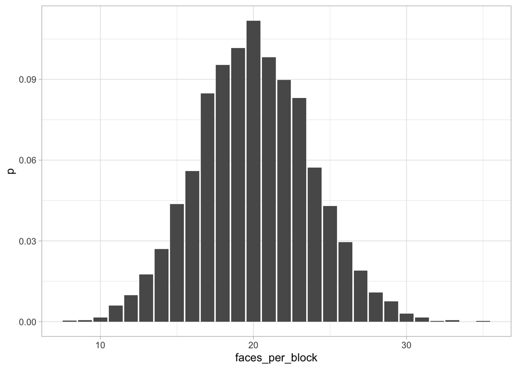

```r
data5k <- tibble(faces_per_block = blocks_5k) %>%
  count(faces_per_block) %>%
  mutate(p = n / 5000)

ggplot(data5k, aes(faces_per_block, p)) + #plot
  geom_col() +
  theme_light()
```

Extracting appropriately from the tibble, what was the probability of seeing only 10 faces in a block? Answer in the cell block below.

```r
q4 <- NULL
```

## Question 5

Using the appropriate `binom()` function, determine the actual probability of seeing exactly 10 ‘face’ trials in a sequence of 60 trials.

```r
q5 <- NULL
```

## Question 6

Using the appropriate `binom()` function, to three decimal places, type in the actual probability of seeing more than, but not including, 25 faces in a block of 60 trials? **Hint: do we want the upper or lower tails of the distribution?**

```r
q6 <- NULL
```

## Question 7

Using the appropriate `binom()` function, enter the number of faces needed in a block of 60 trials that would cut off a lower tail probability of .05.

```r
q7 <- NULL
```